# EPID 722 recitation, 2016/02/08

EPID 722 2016

February 1, 2016

**NOTE: ALL SAS and R code below copied from EPID 722 lecture material from 2016. R code based on Alan Brookhart’s programs titled, “iptw_example.R” and “iptw_example.sas”**

# 1 IPTW

## 1.1 Preliminaries

### 1.1.1 Specify packages for R

```r
  #install.packages("geepack", "ggplot2") # Note: only install once.
require(foreign)
library(boot)
library(geepack)
library(ggplot2)
library(foreach)
library(tableone)
library(survey)
set.seed(101) # set seed so you get same results each time you run. Note: no seed in original Gcomp.R program.
```

## 1.2 Read in NAMCS data – will need to correct the path

### 1.2.1 R

```r
#getwd() # get the working directory
ns=read.dta("../data/nsaid008.dta") # read in data. relative to the working directory go up 1 level and into 'data' folder to read data.
# Otherwise specify full path of data location. for example a path could be c:\temp\nsaid008.dta
#ns=read.dta("c:/temp/nsaid008.dta")
```

### 1.2.2 SAS

```sas
libname a "c:\temp"; # set library containing the permanent SAS data set, nsaid008.sas7bdat.
```

## 1.3 Simulate outcome using logistic regression

### 1.3.1 SAS

```sas
libname a "c:\temp";

/*  compute prob of bleed from known model, simulate outcome using logistic regression  */

DATA a.ns;
   call streaminit(1235);
   SET a.nsaid008;
   pbleed=1/(1+exp(-(-6.75 + .6*contanticoag + 1*tobacco_imp + .5*contsteroids +
                    .2*contaspirin + .7*arthrtis + .07*age + .3*male +
                    .02*raceblkoth- .3*newcox2 )));
   bleed=rand("bernoulli",pbleed);   *simulate the observed outcome;
run;
```

### 1.3.2 R

```r
# Simulate outcome using logistic regression

ns$pbleed=1/(1+exp(-(-6.75 + .6*ns$contanticoag + 1*ns$tobacco_imp + .5*ns$contsteroids +
                       .2*ns$contaspirin + .7*ns$arthrtis + .07*ns$age + .3*ns$male +
                       .02*ns$raceblkoth- .3*ns$newcox2 )))

ns$bleed=rbinom(size=1,n=nrow(ns),p=ns$pbleed)
```

## 1.4 Estimate the (unknown) propensity score, and plot the density by treatment group

Notation for IPTW starting from slide 6 of 32 of IPTW lecture notes, propensityscores.pdf:

$Pr(X=1 \mid C) = expit(\beta_0 + \beta_1 age + \beta_2 sex + \beta_3 CHD + \ldots)$

and

IPTW estimator:

In treated: $\frac{1}{PS(C)}$ and $\frac{1}{1-PS(C)}$ in untreated patients.

SMRW:

In treated=1 and $\frac{PS(C)}{1-PS(C)}$ in untreated patients.

### 1.4.1 SAS

```sas
libname a "c:\temp";

/* create propensity score model */

proc logistic data=a.ns descending;
class newcox2 year;
 model newcox2 = male arthrtis contsteroids contanticoag contaspirin tobacco_imp
                 raceblkoth age ;
 output out=ps_data predicted=ps;
run;

/* Creating PS treatment groups for plotting */

DATA ps_data;
    set ps_data;
    if newcox2 = 1 then treated_ps = ps;
        ELSE treated_ps = .;
    if newcox2 = 0 then untreated_ps = ps;
        else untreated_ps = .;
run;

/* compute inverse-probability of treatment weight and SMR weight */

data a.ps_data;
    set ps_data;
    if newcox2=1 then ps_exp=ps; else ps_unexp=ps;
    iptw=(newcox2/ps) + (1-newcox2)/(1-ps);
    smrw=newcox2+(1-newcox2)*ps/(1-ps);
run;
```

```
## The LOGISTIC Procedure
##
##               Model Information
##
## Data Set                      A.NS
## Response Variable             newcox2
## Number of Response Levels     2
## Model                         binary logit
## Optimization Technique        Fisher's scoring
##
##            Model Information
##
##
## New NSAID user/rcvd Cox-2 selective only
##
##
##
##
##
## Number of Observations Read        2882
## Number of Observations Used        2882
##
##
##           Response Profile
##
##  Ordered                      Total
##    Value      newcox2     Frequency
##
##        1            1           240
##        2            0          2642
##
## Probability modeled is newcox2=1.
##
##
##                     Model Convergence Status
##
##          Convergence criterion (GCONV=1E-8) satisfied.
##
##
##          Model Fit Statistics
```

[output cut: 41 more lines]

```
## arthrtis           1.764       1.339       2.324
## contsteroids       4.129       1.440      11.837
## contanticoag       1.910       0.405       9.014
## contaspirin        0.892       0.437       1.824
## tobacco_imp        1.429       1.002       2.038
## raceblkoth         0.920       0.657       1.290
## age                1.019       1.011       1.027
##
##
## Association of Predicted Probabilities and Observed Responses
##
## Percent Concordant      64.0    Somers' D    0.296
## Percent Discordant      34.4    Gamma        0.301
## Percent Tied             1.5    Tau-a        0.045
## Pairs                 634080    c            0.648
```

### 1.4.2 R

```r
glm.out=glm(newcox2~contanticoag+tobacco_imp+contsteroids+diabetes+contaspirin+arthrtis+age+male+raceblkoth,family=binomial,data=ns)
ns$ps=predict(glm.out,type="response")

# compute IPTW and SMRW weights

ns$iptw=ns$newcox2/ns$ps+(1-ns$newcox2)/(1-ns$ps)
ns$smrw=ns$newcox2+(1-ns$newcox2)*ns$ps/(1-ns$ps)
```

## 1.5 Plots

### 1.5.1 SAS

```
## Propensity score distributions by treatment group
##
## The KDE Procedure
##
##                       Inputs
##
## Data Set                          A.PS_DATA
## Number of Observations Used       2642
## Variable                          untreated_ps
## Bandwidth Method                  Sheather-Jones
##                                   Plug In
##
##
##                Controls
##
##                              untreated_
##                                      ps
##
## Grid Points                         401
## Lower Grid Limit                 0.0333
## Upper Grid Limit                 0.3715
## Bandwidth Multiplier                  1
##
##
##
## Propensity score distributions by treatment group
##
## The KDE Procedure
##
##                       Inputs
##
## Data Set                          A.PS_DATA
## Number of Observations Used       240
## Variable                          treated_ps
## Bandwidth Method                  Sheather-Jones
##                                   Plug In
##
##
##               Controls
##
##                              treated_
##                                    ps
##
## Grid Points                       401
## Lower Grid Limit               0.0345
## Upper Grid Limit               0.3115
## Bandwidth Multiplier                1
```

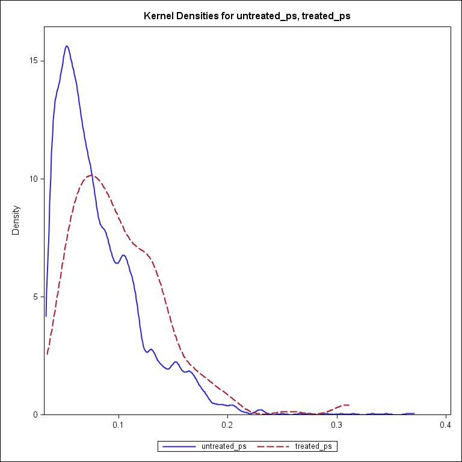

```sas
libname a "c:\temp";

ods listing gpath="c:\\temp";
ods graphics on / reset=all imagename="iptw_sas1" imagefmt=jpeg height=8in width=8in;

/* Plot the overlap of the PS distributions by treatment group */

PROC KDE DATA=a.ps_data;
    UNIVAR untreated_ps treated_ps / PLOTS=densityoverlay;
    TITLE "Propensity score distributions by treatment group";
RUN;
ods graphics off;
```

### 1.5.2 R

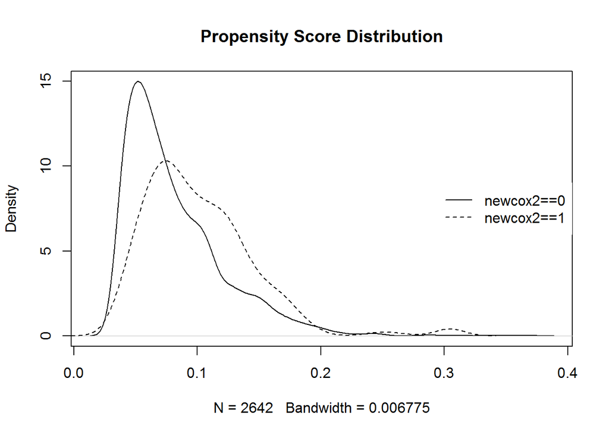

```r
# Estimate the (unknown) propensity score, and plot the density by treatment group

glm.out=glm(newcox2~contanticoag+tobacco_imp+contsteroids+diabetes+contaspirin+arthrtis+age+male+raceblkoth,family=binomial,data=ns)
ns$ps=predict(glm.out,type="response")

plot(density(ns$ps[ns$newcox2==0]),lty=1,main="Propensity Score Distribution")
lines(density(ns$ps[ns$newcox2==1]),lty=2)
legend("right",c("newcox2==0","newcox2==1"),lty=c(1,2),box.col=NA)
```

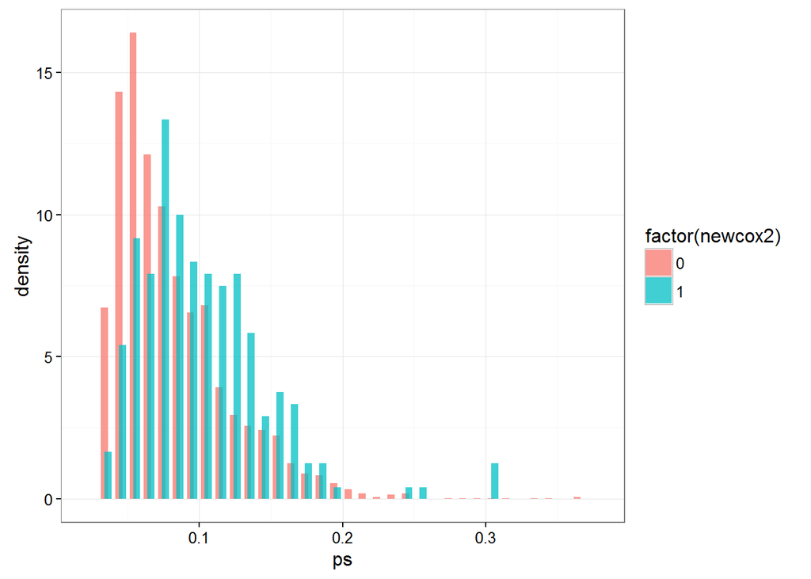

```r
ggplot(data=ns,aes(x=ps,group=factor(newcox2), fill=factor(newcox2)))+
  geom_histogram(aes(y=..density..),alpha = 0.75,binwidth=0.01,
                 position = position_dodge(width=0.005))+theme_bw()
```

## 1.6 Explore Table 1

Note that there are differences between treatment groups when comparing statistics for selected covariates. The treated group is older, uses more tobacco, and has a higher proportion reporting arthritis.

### 1.6.1 SAS

```sas
libname a "c:\temp";

/* explore data, table 1 */

proc means data=a.ns mean;
    class newcox2;
    var male arthrtis contsteroids contanticoag contaspirin tobacco_imp
                 raceblkoth age ;
run;
```

```
## The MEANS Procedure
##
##    New NSAID
##    user/rcvd
##        Cox-2
##    selective      N
##         only    Obs   Variable       Label
## --------------------------------------------------------------------------------
##            0   2642   male           Pt is male
##                       arthrtis       Does patient now have - Arthritis
##                       contsteroids   Continuing adrenal cortical steroids
##                       contanticoag   Continuing anticoagulant
##                       contaspirin    Continuing aspirin
##                       tobacco_imp    Pt uses tobacco (imputed for lab exercises)
##                       raceblkoth     Race Black/Other
##                       age            Patient age in years
##
##            1    240   male           Pt is male
##                       arthrtis       Does patient now have - Arthritis
##                       contsteroids   Continuing adrenal cortical steroids
##                       contanticoag   Continuing anticoagulant
##                       contaspirin    Continuing aspirin
##                       tobacco_imp    Pt uses tobacco (imputed for lab exercises)
##                       raceblkoth     Race Black/Other
##                       age            Patient age in years
## --------------------------------------------------------------------------------
##
##    New NSAID
##    user/rcvd
##        Cox-2
##    selective      N
##         only    Obs   Variable               Mean
## -------------------------------------------------
##            0   2642   male              0.4125662
##                       arthrtis          0.3001514
##                       contsteroids      0.0049205
##                       contanticoag      0.0034065
##                       contaspirin       0.0314156
##                       tobacco_imp       0.1502650
##                       raceblkoth        0.2119606
##                       age              47.2956094
##
##            1    240   male              0.4166667
##                       arthrtis          0.4666667
##                       contsteroids      0.0208333
##                       contanticoag      0.0083333
##                       contaspirin       0.0375000
##                       tobacco_imp       0.1791667
##                       raceblkoth        0.1958333
##                       age              53.4291667
## -------------------------------------------------
```

### 1.6.2 R

```r
t.1 = CreateTableOne(vars=c("male", "arthrtis", "contsteroids",
                            "containticoag", "contaspirin", "tobacco_imp",
                            "raceblkoth", "age"),
                     strata = c("newcox2"),
                     data = ns,
                     test=F)
print(t.1)#, #nonnormal=c("contanticoag"))
```

```
##                           Stratified by newcox2
##                            0             1
##   n                         2642           240
##   male (mean (sd))          0.41 (0.49)   0.42 (0.49)
##   arthrtis (mean (sd))      0.30 (0.46)   0.47 (0.50)
##   contsteroids (mean (sd))  0.00 (0.07)   0.02 (0.14)
##   contaspirin (mean (sd))   0.03 (0.17)   0.04 (0.19)
##   tobacco_imp (mean (sd))   0.15 (0.36)   0.18 (0.38)
##   raceblkoth (mean (sd))    0.21 (0.41)   0.20 (0.40)
##   age (mean (sd))          47.30 (16.64) 53.43 (15.72)
```

## 1.7 IPT weighted table 1

### 1.7.1 SAS

```sas
libname a "c:\temp";

/* IPT weighted table 1 */

proc means data=a.ps_data mean;
    class newcox2;
    var male arthrtis contsteroids contanticoag contaspirin tobacco_imp
                 raceblkoth age ;
        weight iptw;
run;
```

```
## The MEANS Procedure
##
##    New NSAID
##    user/rcvd
##        Cox-2
##    selective      N
##         only    Obs   Variable       Label
## --------------------------------------------------------------------------------
##            0   2642   male           Pt is male
##                       arthrtis       Does patient now have - Arthritis
##                       contsteroids   Continuing adrenal cortical steroids
##                       contanticoag   Continuing anticoagulant
##                       contaspirin    Continuing aspirin
##                       tobacco_imp    Pt uses tobacco (imputed for lab exercises)
##                       raceblkoth     Race Black/Other
##                       age            Patient age in years
##
##            1    240   male           Pt is male
##                       arthrtis       Does patient now have - Arthritis
##                       contsteroids   Continuing adrenal cortical steroids
##                       contanticoag   Continuing anticoagulant
##                       contaspirin    Continuing aspirin
##                       tobacco_imp    Pt uses tobacco (imputed for lab exercises)
##                       raceblkoth     Race Black/Other
##                       age            Patient age in years
## --------------------------------------------------------------------------------
##
##    New NSAID
##    user/rcvd
##        Cox-2
##    selective      N
##         only    Obs   Variable               Mean
## -------------------------------------------------
##            0   2642   male              0.4129724
##                       arthrtis          0.3144799
##                       contsteroids      0.0063022
##                       contanticoag      0.0038346
##                       contaspirin       0.0317752
##                       tobacco_imp       0.1527029
##                       raceblkoth        0.2106771
##                       age              47.8209480
##
##            1    240   male              0.4192798
##                       arthrtis          0.3382471
##                       contsteroids      0.0066117
##                       contanticoag      0.0039612
##                       contaspirin       0.0290179
##                       tobacco_imp       0.1545726
##                       raceblkoth        0.2124116
##                       age              49.1229179
## -------------------------------------------------
```

### 1.7.2 R

```r
# Table 1
covs=c("male","age","diabetes","arthrtis","copd",
       "reas1digest","tobacco_imp","contsteroids")
ret=foreach(var=covs,.combine="rbind") %do%
  c(mean(ns[ns$newcox2==0,var]),mean(ns[ns$newcox2==1,var]))
row.names(ret)<-covs
colnames(ret)<-c("Old NSAIDS","Cox-2 Sel NSAIDs")
round(ret,2)
```

```
##              Old NSAIDS Cox-2 Sel NSAIDs
## male               0.41             0.42
## age               47.30            53.43
## diabetes           0.08             0.13
## arthrtis           0.30             0.47
## copd               0.02             0.03
## reas1digest        0.03             0.04
## tobacco_imp        0.15             0.18
## contsteroids       0.00             0.02
```

```r
# Compute Table 1 statistics for IPTW sample
ret=foreach(var=covs,.combine="rbind") %do%
  c(sum(ns[,var]*ns$iptw*ns$newcox2),sum(ns[,var]*ns$iptw*(1-ns$newcox2)))/nrow(ns)
row.names(ret)<-covs
colnames(ret)<-c("Old NSAIDS","Cox-2 Sel NSAIDs")
round(ret,2)
```

```
##              Old NSAIDS Cox-2 Sel NSAIDs
## male               0.41             0.41
## age               47.86            47.84
## diabetes           0.10             0.09
## arthrtis           0.33             0.31
## copd               0.02             0.02
## reas1digest        0.05             0.03
## tobacco_imp        0.15             0.15
## contsteroids       0.01             0.01
```

**Note** that the weighted distribution of the covariates is now similar to the entire population.

Distribution of the covariates for the entire sample:

```
##
##                            Overall
##   n                         2882
##   male (mean (sd))          0.41 (0.49)
##   arthrtis (mean (sd))      0.31 (0.46)
##   contsteroids (mean (sd))  0.01 (0.08)
##   contanticoag (mean (sd))  0.00 (0.06)
##   contaspirin (mean (sd))   0.03 (0.18)
##   tobacco_imp (mean (sd))   0.15 (0.36)
##   raceblkoth (mean (sd))    0.21 (0.41)
##   age (mean (sd))          47.81 (16.65)
```

## 1.8 SMR weighted table 1

### 1.8.1 SAS

```sas
libname a "c:\temp";

/* SMR weighted table 1 */

proc means data=a.ps_data mean;
    class newcox2;
    var male arthrtis contsteroids contanticoag contaspirin tobacco_imp
                 raceblkoth age ;
        weight smrw;
run;
```

```
## The MEANS Procedure
##
##    New NSAID
##    user/rcvd
##        Cox-2
##    selective      N
##         only    Obs   Variable       Label
## --------------------------------------------------------------------------------
##            0   2642   male           Pt is male
##                       arthrtis       Does patient now have - Arthritis
##                       contsteroids   Continuing adrenal cortical steroids
##                       contanticoag   Continuing anticoagulant
##                       contaspirin    Continuing aspirin
##                       tobacco_imp    Pt uses tobacco (imputed for lab exercises)
##                       raceblkoth     Race Black/Other
##                       age            Patient age in years
##
##            1    240   male           Pt is male
##                       arthrtis       Does patient now have - Arthritis
##                       contsteroids   Continuing adrenal cortical steroids
##                       contanticoag   Continuing anticoagulant
##                       contaspirin    Continuing aspirin
##                       tobacco_imp    Pt uses tobacco (imputed for lab exercises)
##                       raceblkoth     Race Black/Other
##                       age            Patient age in years
## --------------------------------------------------------------------------------
##
##    New NSAID
##    user/rcvd
##        Cox-2
##    selective      N
##         only    Obs   Variable               Mean
## -------------------------------------------------
##            0   2642   male              0.4174296
##                       arthrtis          0.4717215
##                       contsteroids      0.0214644
##                       contanticoag      0.0085329
##                       contaspirin       0.0357210
##                       tobacco_imp       0.1794566
##                       raceblkoth        0.1965920
##                       age              53.5860329
##
##            1    240   male              0.4166667
##                       arthrtis          0.4666667
##                       contsteroids      0.0208333
##                       contanticoag      0.0083333
##                       contaspirin       0.0375000
##                       tobacco_imp       0.1791667
##                       raceblkoth        0.1958333
##                       age              53.4291667
## -------------------------------------------------
```

### 1.8.2 R

```r
my.smrw <- svydesign(id=~patcode, data = ns, weight = ~smrw)
names(ns)
```

```
##  [1] "year"             "phycode"          "patcode"
##  [4] "msa"              "region"           "northeast"
##  [7] "midwest"          "south"            "west"
## [10] "spec"             "specr"            "speccat"
## [13] "pcdoc"            "surgspec"         "medspec"
## [16] "cvdspec"          "mddo"             "do"
## [19] "age"              "male"             "racer"
## [22] "raceblkoth"       "pripayer"         "mcaidselfnc_imp"
## [25] "urbanrur0609"     "nonmetro0609"     "hinczip0609"
## [28] "lowinczip0609"    "pctpov0609"       "hipovzip0609"
## [31] "pctbamore0609"    "major"            "reason1"
## [34] "reason2"          "reason3"          "reas1circ"
## [37] "reas1resp"        "reas1digest"      "reas1musc"
## [40] "reasoncirc"       "reasonresp"       "reasondigest"
## [43] "reasonmusc"       "cam"              "arthrtis"
## [46] "asthma"           "cancer"           "cebvd"
## [49] "crf"              "chf"              "copd"
## [52] "deprn"            "diabetes"         "hyplipid"
## [55] "htn"              "ihd"              "ostprsis"
## [58] "totchron_imp"     "multchron_imp"    "surgflare_imp"
## [61] "surgchron_imp"    "bpsys"            "bpdias"
## [64] "tobacco_imp"      "bp_stage2"        "bp_stage1"
## [67] "bp_prehtn"        "cox2"             "nsnsaid"
## [70] "newcox2"          "newnsnsaid"       "contnsaid"
## [73] "contaht"          "contstatin"       "conth2antagonist"
## [76] "contppi"          "contaspirin"      "contanticoag"
## [79] "contsteroids"     "pud"              "pbleed"
## [82] "bleed"            "ps"               "iptw"
## [85] "smrw"
```

```r
t.1.smrw = svyCreateTableOne(vars=c("male", "arthrtis", "contsteroids",
                            "contanticoag", "contaspirin", "tobacco_imp",
                            "raceblkoth", "age"),
                     strata = c("newcox2"),
                     data=my.smrw,
                     test=F)
print(t.1.smrw)#, #nonnormal=c("contanticoag"))
```

```
##                           Stratified by newcox2
##                            0              1
##   n                        240.97         240.00
##   male (mean (sd))           0.42 (0.49)    0.42 (0.49)
##   arthrtis (mean (sd))       0.47 (0.50)    0.47 (0.50)
##   contsteroids (mean (sd))   0.02 (0.15)    0.02 (0.14)
##   contanticoag (mean (sd))   0.01 (0.09)    0.01 (0.09)
##   contaspirin (mean (sd))    0.04 (0.19)    0.04 (0.19)
##   tobacco_imp (mean (sd))    0.18 (0.38)    0.18 (0.38)
##   raceblkoth (mean (sd))     0.20 (0.40)    0.20 (0.40)
##   age (mean (sd))           53.60 (16.94)  53.43 (15.72)
```

**Note** that the weighted distribution of the covariates is now similar to the treated sample.

Distribution of the covariates for the treated sample:

```
##
##                            Overall
##   n                          240
##   male (mean (sd))          0.42 (0.49)
##   arthrtis (mean (sd))      0.47 (0.50)
##   contsteroids (mean (sd))  0.02 (0.14)
##   contanticoag (mean (sd))  0.01 (0.09)
##   contaspirin (mean (sd))   0.04 (0.19)
##   tobacco_imp (mean (sd))   0.18 (0.38)
##   raceblkoth (mean (sd))    0.20 (0.40)
##   age (mean (sd))          53.43 (15.72)
```

## 1.9 Unweighted regression, crude

### 1.9.1 SAS

```sas
libname a "c:\temp";

/* unweighted regression, crude */

proc genmod data=a.ps_data desc;
    model bleed=newcox2 / dist=binomial link=identity;
run; quit;
```

```
## The GENMOD Procedure
##
##        Model Information
##
## Data Set              A.PS_DATA
## Distribution           Binomial
## Link Function          Identity
## Dependent Variable        bleed
##
##
## Number of Observations Read        2882
## Number of Observations Used        2882
## Number of Events                    263
## Number of Trials                   2882
##
##
##        Response Profile
##
##  Ordered                 Total
##    Value    bleed    Frequency
##
##        1    1              263
##        2    0             2619
##
## PROC GENMOD is modeling the probability that bleed='1'.
##
##
##              Criteria For Assessing Goodness Of Fit
##
## Criterion                     DF           Value        Value/DF
##
## Log Likelihood                         -880.1440
## Full Log Likelihood                    -880.1440
## AIC (smaller is better)                1764.2881
## AICC (smaller is better)               1764.2923
## BIC (smaller is better)                1776.2206
##
##
## Algorithm converged.
##
##
##              Analysis Of Maximum Likelihood Parameter Estimates
##
##                          Standard       Wald 95%             Wald
## Parameter  DF  Estimate     Error   Confidence Limits  Chi-Square  Pr > ChiSq
##
## Intercept   1    0.0905    0.0056    0.0795    0.1014      262.77      <.0001
## newcox2     1    0.0095    0.0202   -0.0300    0.0490        0.22      0.6360
## Scale       0    1.0000    0.0000    1.0000    1.0000
##
## NOTE: The scale parameter was held fixed.
```

### 1.9.2 R

```r
# Unweighted regression, crude
m.1 = glm(bleed~newcox2, family=gaussian(link="identity"), data=ns)
coef(summary(m.1))
```

```
##               Estimate  Std. Error    t value     Pr(>|t|)
## (Intercept) 0.09689629 0.005799575 16.7074819 6.975154e-60
## newcox2     0.01977038 0.020097291  0.9837334 3.253293e-01
```

```r
coef(summary(update(m.1, family=binomial(link="identity"))))
```

```
##               Estimate  Std. Error    z value     Pr(>|z|)
## (Intercept) 0.09689629 0.005755141 16.8364750 1.318612e-63
## newcox2     0.01977038 0.021506273  0.9192841 3.579470e-01
```

*Interpretation*: The coefficient for **newcox2**, 0.0198, suggests that there are 1.98 more cases of bleeding per 100 people in the treated group (newcox2=1) compared to the untreated group. Note this is the crude model with no adjustment in this model.

## 1.10 Estimate causal risk difference in the population using **IPT-weighted** linear regression

### 1.10.1 SAS

```sas
libname a "c:\temp";

/* estimate causal risk difference in the population using IPT-weighted linear regression */

ods select GEEEmpPEst geemodinfo;
proc genmod data=a.ps_data desc;
    class patcode;
    model bleed=newcox2 /dist=bin link=identity;
    repeated subject=patcode / corr=ind;
    weight iptw;
run;

/* Note you get same results regardless of distribution. */
ods select GEEEmpPEst geemodinfo;
proc genmod data=a.ps_data desc;
    class patcode;
    model bleed=newcox2 /dist=normal link=identity;
    repeated subject=patcode / corr=ind;
    weight iptw;
run;
```

```
## The GENMOD Procedure
##
##                 GEE Model Information
##
## Correlation Structure                     Independent
## Subject Effect                  patcode (2882 levels)
## Number of Clusters                               2882
## Correlation Matrix Dimension                        1
## Maximum Cluster Size                                1
## Minimum Cluster Size                                1
##
##
##              Analysis Of GEE Parameter Estimates
##               Empirical Standard Error Estimates
##
##                    Standard   95% Confidence
## Parameter Estimate    Error       Limits            Z Pr > |Z|
##
## Intercept   0.0942   0.0058   0.0829   0.1056   16.25   <.0001
## newcox2    -0.0231   0.0164  -0.0551   0.0090   -1.41   0.1585
##
##
##
## The GENMOD Procedure
##
##                 GEE Model Information
##
## Correlation Structure                     Independent
## Subject Effect                  patcode (2882 levels)
## Number of Clusters                               2882
## Correlation Matrix Dimension                        1
## Maximum Cluster Size                                1
## Minimum Cluster Size                                1
##
##
##              Analysis Of GEE Parameter Estimates
##               Empirical Standard Error Estimates
##
##                    Standard   95% Confidence
## Parameter Estimate    Error       Limits            Z Pr > |Z|
##
## Intercept   0.0942   0.0058   0.0829   0.1056   16.25   <.0001
## newcox2    -0.0231   0.0164  -0.0551   0.0090   -1.41   0.1585
```

### 1.10.2 R

```r
m.2 = geeglm(bleed~newcox2, family=gaussian, weight=iptw, id=patcode, data=ns)
# IPT weighted, use GEE for SE
coef(summary(m.2))
```

```
##               Estimate    Std.err       Wald  Pr(>|W|)
## (Intercept)  0.1013983 0.00600130 285.476795 0.0000000
## newcox2     -0.0222170 0.01650539   1.811836 0.1782881
```

```r
coef(summary(update(m.2, family=binomial(link="identity")))) # note that you get same results
```

```
##               Estimate    Std.err       Wald  Pr(>|W|)
## (Intercept)  0.1013983 0.00600130 285.476795 0.0000000
## newcox2     -0.0222170 0.01650539   1.811836 0.1782881
```

**Interpretation**: The coefficient for **newcox2**, -0.0222, suggests that there are -2.22 fewer cases of bleeding per 100 people in the treated group (newcox2=1) compared to the untreated group in the entire study population.

## 1.11 Estimate causal risk difference in the population using **SMR-weighted** linear regression

### 1.11.1 SAS

```sas
libname a "c:\temp";

/* estimate causal risk difference in the population using SMR-weighted linear regression */

ods select GEEEmpPEst geemodinfo;
proc genmod data=a.ps_data desc;
    class patcode;
    model bleed=newcox2 /dist=bin link=identity;
    repeated subject=patcode / corr=ind;
    weight smrw;
run;
```

```
## The GENMOD Procedure
##
##                 GEE Model Information
##
## Correlation Structure                     Independent
## Subject Effect                  patcode (2882 levels)
## Number of Clusters                               2882
## Correlation Matrix Dimension                        1
## Maximum Cluster Size                                1
## Minimum Cluster Size                                1
##
##
##              Analysis Of GEE Parameter Estimates
##               Empirical Standard Error Estimates
##
##                    Standard   95% Confidence
## Parameter Estimate    Error       Limits            Z Pr > |Z|
##
## Intercept   0.1355   0.0089   0.1181   0.1528   15.29   <.0001
## newcox2    -0.0355   0.0213  -0.0772   0.0063   -1.67   0.0957
```

### 1.11.2 R

```r
# SMR weighted, use GEE for SE
m.3 = geeglm(bleed~newcox2, family=gaussian, weight=smrw, id=patcode, data=ns)
coef(summary(m.3))
```

```
##                Estimate     Std.err       Wald  Pr(>|W|)
## (Intercept)  0.15075815 0.009256837 265.238368 0.0000000
## newcox2     -0.03409148 0.022695532   2.256374 0.1330653
```

```r
coef(summary(update(m.3, family=binomial(link = "identity"))))
```

```
##                Estimate     Std.err       Wald  Pr(>|W|)
## (Intercept)  0.15075815 0.009256837 265.238368 0.0000000
## newcox2     -0.03409148 0.022695532   2.256374 0.1330653
```

*Interpretation*: The coefficient for **newcox2**, -0.0341, suggests that there are -3.41 fewer cases of bleeding per 100 people in the treated group (newcox2=1) compared to the untreated group in the population “whose distribution of risk factors” (1) is equal to that for the treated patients only.

## 1.12 Appendix: Normal approximation to the binomial distribution.

Bleed is a binomially distribution variable with $bleed \sim bin(n,p)$ and $p = Pr(X=k) = \dbinom{n}{k} p^k (1-p)^{n-k}$.

The count of X bleeds in a group of $n$ observations with a probability of $p$ follows an approximately normal distribution for large values of n courtesy of the Central Limit Theorem, with $\hat{p} \textrm{ approximately } \sim N\left(p, \displaystyle\frac{p(1-p)}{n}\right)$.

See [this link](http://www.stat.yale.edu/Courses/1997-98/101/binom.htm) for info on Normal approximation of Binomial distribution.

### 1.12.1 R

Proportion of bleeding in sample by treatment status (newcox2)

```r
app.smrw = svyCreateTableOne(vars=c("bleed"),
                     strata = c("newcox2"),
                     factorVars = c("bleed"),
                     data=my.smrw,
                     test=F)
print(app.smrw)
```

```
##                Stratified by newcox2
##                 0             1
##   n             241.0         240.0
##   bleed = 1 (%)  36.3 (15.1)   28.0 (11.7)
```

References

1. Kurth T. Results of Multivariable Logistic Regression, Propensity Matching, Propensity Adjustment, and Propensity-based Weighting under Conditions of Nonuniform Effect. *Am. J. Epidemiol.* [electronic article]. 2005;163(3):262–270. (http://aje.oxfordjournals.org/cgi/doi/10.1093/aje/kwj047)